# Analysis of Music and Mental Health

Shruthi Rajesh and Gayatri Gopavajhala\ CMSC320\ Final Tutorial Project \

# 1 Introduction

Music is well known to affect a variety of neurobiological processes in the brain. While the media has blamed certain genres of music (mainly rock, metal and rap) for the cause of mental health issues, studies that have investigated this connection found a correlation the other way around. People who have mental health issues like certain genres, not the other way around. (Bake, Bor, 2008)

However, music therapy is a common alternative therapy to help witha variety of health treatments, including mental health. (Lin, et al., 2011) Music therapy involves listening, playing, singing and/or composing music in order to help with ones health. While the effects of music on helping with treatments is not fully understood, we do know that music can have an effect on one's mental state.

The correlation between music and mental health is not strong in either direction. Both of them can affect the othe.

(Both of the people working on this are mentally ill and understand that both mental illness and music taste can be caused by a variety of factors, we are simply trying to find any correlations we are not claiming any causations either way.)

# 2 Data

We import a variety of libraries to help us with the project.\ pandas: a package that helps us build dataframes \ matplotlib.pyplot: a package to help us plot graphs\ seaborn: also a package to help us plot graphs\ statsmodels.api: a package to help us do statistical testing\ statsmodels.formula.api: another package to help with statistical testing \ numpy: a package to help with manipulating arrays and for matrices\ warning: a package to help with limiting the amount of warnings that show up

```python
import pandas as pd
%matplotlib inline
import matplotlib.pyplot as plt
import seaborn as sns
import statsmodels.api as sm
import statsmodels.formula.api as smf
import numpy as np
import requests
import warnings
sns.set_theme()
warnings.filterwarnings('ignore')
mxmh = pd.read_csv("mxmh_survey_results.csv")
```

We are using warnings here to suppress all the warnings coming from making the graphs.

Our dataset was inputed as a csv file, so we read it into a dataframe called mxmh.

We are attempting to investigate the connections between people's music preferences and their mental health. We are using a dataset from [kaggle](https://www.kaggle.com/datasets/catherinerasgaitis/mxmh-survey-results). This dataset was compiled from a survey asking people for their music preferences and how they interact with music, as well as questions about their mental state.

The columns are: \ Age: age of participant\ Primary streaming service: the main service they use to listen to music\ Hours per day: how many hours do they listen to music in a day\ While working: do they listen to music while working\ Composer: do they compose music\ Fav genre: what their favorite genre is\ Exploratory: do they actively explore new genres\ Foreign languages: do they listen to music in languages they don't know\ BPM: what BPM is the music they usually listen to\ Frequency[...]: How frequently they listen to this genre of music (there's one column for each genre)\ Anxiety: How extreme their anxiety is on a scale of 0-10\ Depression: How extreme their depression is on a scale of 0-10\ Incomnia: How extreme their insomnia is on a scale of 0-10\ OCD: How extreme their OCD on a scale of 0-10\ Music effects: How does music affect their lives

(Timestamps of when people filled out the form and, the column of them consenting to their information being released have been dropped as they are unnecessary for this project.)

```python
mxmh.drop(columns=["Permissions","Timestamp"])
```

|  | Age | Primary streaming service | Hours per day | While working | Instrumentalist | Composer | Fav genre | Exploratory | Foreign languages | BPM | ... | Frequency [Pop] | Frequency [R&B] | Frequency [Rap] | Frequency [Rock] | Frequency [Video game music] | Anxiety | Depression | Insomnia | OCD | Music effects |
| --- | --- | --- | --- | --- | --- | --- | --- | --- | --- | --- | --- | --- | --- | --- | --- | --- | --- | --- | --- | --- | --- |
| 0 | 18.0 | Spotify | 3.0 | Yes | Yes | Yes | Latin | Yes | Yes | 156.0 | ... | Very frequently | Sometimes | Very frequently | Never | Sometimes | 3.0 | 0.0 | 1.0 | 0.0 | NaN |
| 1 | 63.0 | Pandora | 1.5 | Yes | No | No | Rock | Yes | No | 119.0 | ... | Sometimes | Sometimes | Rarely | Very frequently | Rarely | 7.0 | 2.0 | 2.0 | 1.0 | NaN |
| 2 | 18.0 | Spotify | 4.0 | No | No | No | Video game music | No | Yes | 132.0 | ... | Rarely | Never | Rarely | Rarely | Very frequently | 7.0 | 7.0 | 10.0 | 2.0 | No effect |
| 3 | 61.0 | YouTube Music | 2.5 | Yes | No | Yes | Jazz | Yes | Yes | 84.0 | ... | Sometimes | Sometimes | Never | Never | Never | 9.0 | 7.0 | 3.0 | 3.0 | Improve |
| 4 | 18.0 | Spotify | 4.0 | Yes | No | No | R&B | Yes | No | 107.0 | ... | Sometimes | Very frequently | Very frequently | Never | Rarely | 7.0 | 2.0 | 5.0 | 9.0 | Improve |
| ... | ... | ... | ... | ... | ... | ... | ... | ... | ... | ... | ... | ... | ... | ... | ... | ... | ... | ... | ... | ... | ... |
| 731 | 17.0 | Spotify | 2.0 | Yes | Yes | No | Rock | Yes | Yes | 120.0 | ... | Very frequently | Never | Rarely | Very frequently | Never | 7.0 | 6.0 | 0.0 | 9.0 | Improve |
| 732 | 18.0 | Spotify | 1.0 | Yes | Yes | No | Pop | Yes | Yes | 160.0 | ... | Very frequently | Never | Never | Sometimes | Sometimes | 3.0 | 2.0 | 2.0 | 5.0 | Improve |
| 733 | 19.0 | Other streaming service | 6.0 | Yes | No | Yes | Rap | Yes | No | 120.0 | ... | Sometimes | Sometimes | Sometimes | Rarely | Rarely | 2.0 | 2.0 | 2.0 | 2.0 | Improve |
| 734 | 19.0 | Spotify | 5.0 | Yes | Yes | No | Classical | No | No | 170.0 | ... | Never | Never | Never | Never | Sometimes | 2.0 | 3.0 | 2.0 | 1.0 | Improve |
| 735 | 29.0 | YouTube Music | 2.0 | Yes | No | No | Hip hop | Yes | Yes | 98.0 | ... | Sometimes | Very frequently | Very frequently | Very frequently | Rarely | 2.0 | 2.0 | 2.0 | 5.0 | Improve |

736 rows × 31 columns

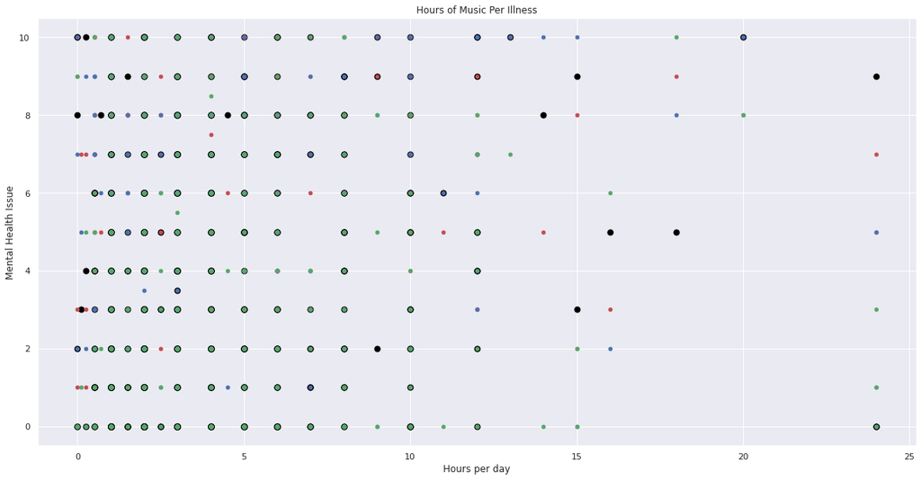

```python
ax1 = mxmh.plot(kind='scatter',x='Hours per day',y='Insomnia',color='black',figsize=(20,10), s=50, title='Hours of Music Per Illness')
ax2 = mxmh.plot(kind='scatter',x='Hours per day',y='Anxiety',color='r',ax=ax1)
ax3 = mxmh.plot(kind='scatter',x='Hours per day',y='Depression',color='b',ax=ax1)
ax2 = mxmh.plot(kind='scatter',x='Hours per day',y='OCD',color='g',ax=ax1)
ax1.set_ylabel("Mental Health Issue")
```

# 3 Exploration

This is a scatter plot of how many hours per day they listen to music against how high they reported their experience with each mental health issue. \ Insomnia: black\ Anxiety: red\ Depression: blue\ OCD: green\ This is very hard to read so let's try a different way to compare these.

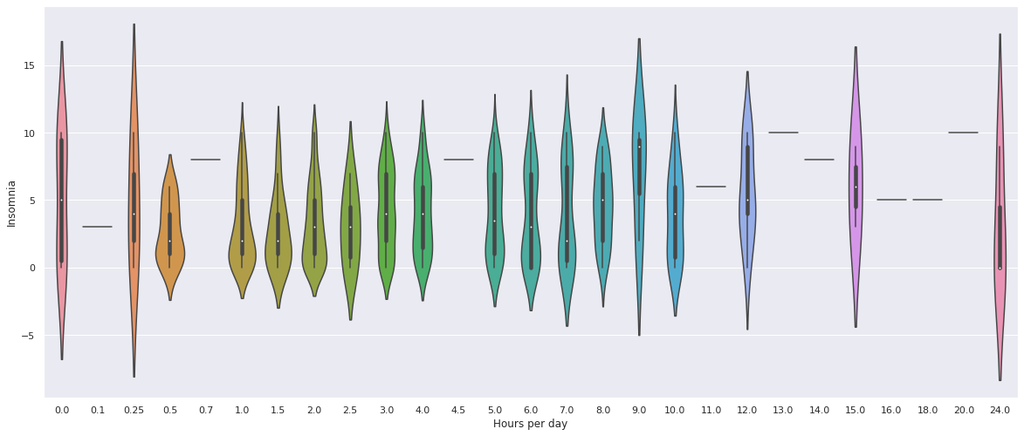

```python
fig, ax = plt.subplots()
fig.set_size_inches(20, 8.27)
sns.violinplot(data=mxmh,x='Hours per day',y='Insomnia',title="Violin Plot of hours per day versus Insomnia")
```

This is a violin plot of hours of music listened to a day vs how high their insomnia rating was. This is more readable but it's hard to compare to other plots and it seems to be straight lines more or less.

```python
m1 = mxmh.groupby("Hours per day")["Insomnia"].mean()
m2 = mxmh.groupby("Hours per day")["Anxiety"].mean()
m3 = mxmh.groupby("Hours per day")["OCD"].mean()
m4 = mxmh.groupby("Hours per day")["Depression"].mean()
```

A group was made for each mental health condition that has the mean of each mental health condition for the different amount of hours per day that they listened to music.

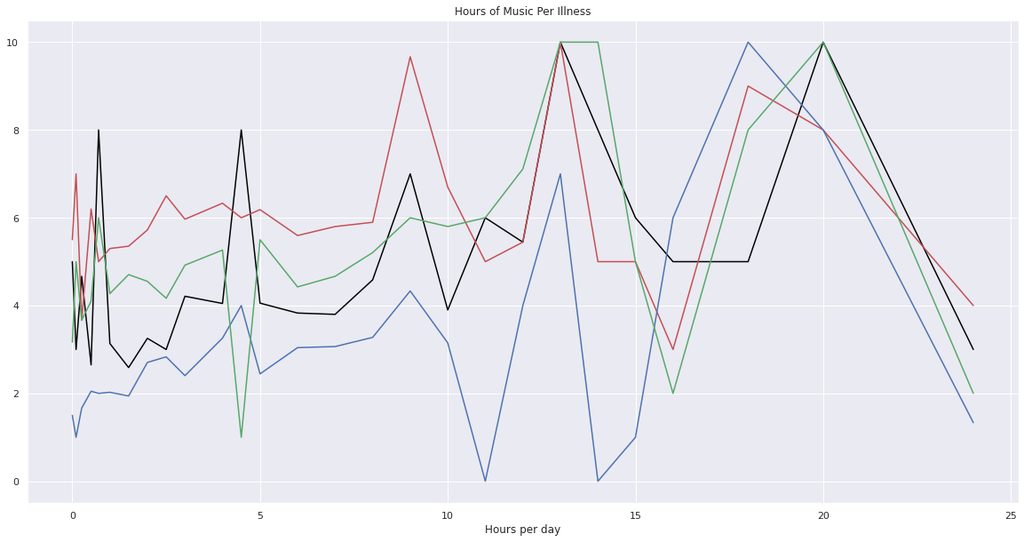

```python
ax1 = m1.plot(x='Hours per day',y='Insomnia',color='black',figsize=(20,10), title='Hours of Music Per Illness')
ax2 = m2.plot(x='Hours per day',y='Anxiety',color='r',ax=ax1)
ax3 = m3.plot(x='Hours per day',y='Depression',color='b',ax=ax1)
ax2 = m4.plot(x='Hours per day',y='OCD',color='g',ax=ax1)
```

But there wasn't really any clear trend so we will come back to this later when we run statistical tests.

```python
boolean_mxmh = mxmh.copy()
#Create the boolean values for if you have smth or not based on if your rating was > 5 on a scale of 10
illnesses = ['Anxiety', 'Depression', 'Insomnia', 'OCD']
totals = {}
for i in illnesses:
  boolean_mxmh[i] = boolean_mxmh.apply(lambda x: round(x[i]/10), axis=1)
  totals[i] = sum(list(boolean_mxmh[i]))

#Add the booleans for if you have any mental illness or if you have none of the ones listed
boolean_mxmh['None'] = boolean_mxmh.apply(lambda x: int(sum([x[i] for i in illnesses]) == 0), axis=1)
boolean_mxmh['Something'] = boolean_mxmh.apply(lambda x: int(sum([x[i] for i in illnesses]) != 0), axis=1)
illnesses.append('None')
illnesses.append('Something')
totals['None'] = sum(list(boolean_mxmh['None']))
totals['Something'] = sum(list(boolean_mxmh['Something']))

#Group by genre and create percentages for comparison
genredf = boolean_mxmh[['Fav genre'] + illnesses].groupby('Fav genre').sum()
for i in illnesses:
  genredf[i] = genredf[i] / totals[i]
genredf_copy = genredf.copy()
print(totals)
genredf.head(10)
```

```
{'Anxiety': 444, 'Depression': 344, 'Insomnia': 231, 'OCD': 131, 'None': 171, 'Something': 565}
```

| Fav genre | Anxiety | Depression | Insomnia | OCD | None | Something |
| --- | --- | --- | --- | --- | --- | --- |
| Classical | 0.060811 | 0.063953 | 0.060606 | 0.038168 | 0.122807 | 0.056637 |
| Country | 0.031532 | 0.023256 | 0.017316 | 0.030534 | 0.046784 | 0.030088 |
| EDM | 0.045045 | 0.055233 | 0.051948 | 0.076336 | 0.052632 | 0.049558 |
| Folk | 0.051802 | 0.040698 | 0.038961 | 0.022901 | 0.017544 | 0.047788 |
| Gospel | 0.006757 | 0.002907 | 0.012987 | 0.000000 | 0.017544 | 0.005310 |
| Hip hop | 0.051802 | 0.066860 | 0.034632 | 0.038168 | 0.017544 | 0.056637 |
| Jazz | 0.029279 | 0.026163 | 0.030303 | 0.022901 | 0.035088 | 0.024779 |
| K pop | 0.036036 | 0.029070 | 0.025974 | 0.030534 | 0.046784 | 0.031858 |
| Latin | 0.002252 | 0.002907 | 0.004329 | 0.000000 | 0.005848 | 0.003540 |
| Lofi | 0.015766 | 0.020349 | 0.025974 | 0.022901 | 0.000000 | 0.017699 |

totals ia a dictionary that has each illness (along with None for no illness and Something for some illness) and how many people belong in each category.

(The sum of all the illnesses does not add to the value of Something, this is because some peopl had high rates of multiple illnesses.

None and Something are created separately as columns in mxmh_copy and then pushed to illness.

Then genredf is created with just the 6 columns (the 4 mental health issues and then None and Something) and then sum of how many people who like a certain genre have that condition.

These are then divided by the total number of people that reported high values for each column (pulled from total.)

This gives us a table that is normalized for the amount of people who have each condition that we can now use to make graphs.

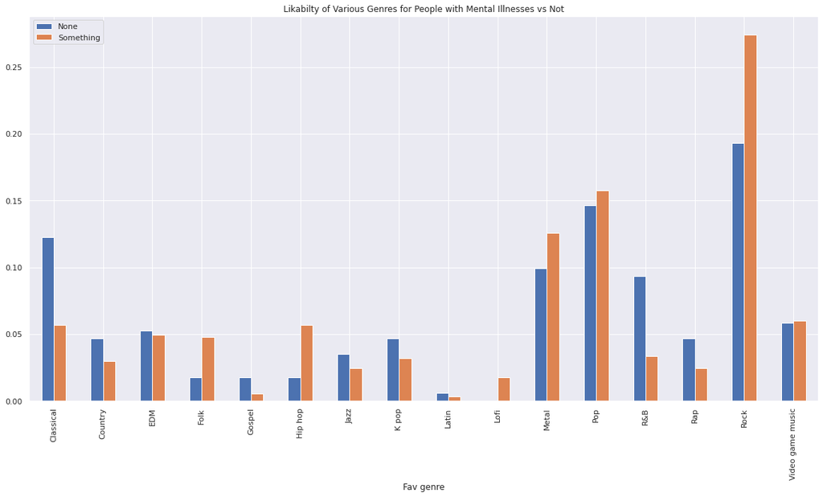

```python
fig, ax = plt.subplots(figsize=(20, 10))
genredf.plot(y=['None', 'Something'], kind="bar", ax=ax)
ax.set_title("Likabilty of Various Genres for People with Mental Illnesses vs Not")
```

This is graph of favorite genre's versus how many people who like that genre have some condition or none. (Using the Something and None columns from genredf.)

Rock stands out as the one with the greatest difference with a 0.08 difference betwen the two bars. Classical has what looks like a 0.06 difference between its bars. R&B looks to have around a 0.05 difference. The rest of them have minimal differences between them. This will come back later when we run statistical tests.

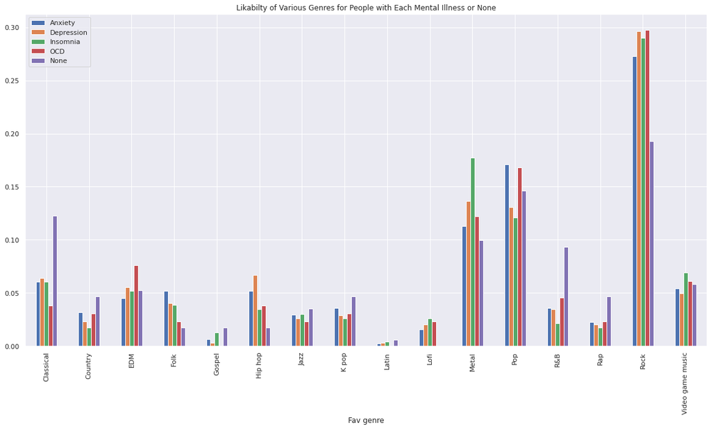

```python
fig, ax = plt.subplots(figsize=(20, 10))
illnesses = [x for x in illnesses if x != "Something"]
genredf.plot(y=illnesses, kind="bar", ax=ax)
#This is based on percentages of all ppl with that illness
ax.set_title("Likabilty of Various Genres for People with Each Mental Illness or None")
```

This is a comparison to show how many people who have a favorite genre also reported a high value for any of the mental health issues (including None.) This is what percentage of people with each condition like each genre.

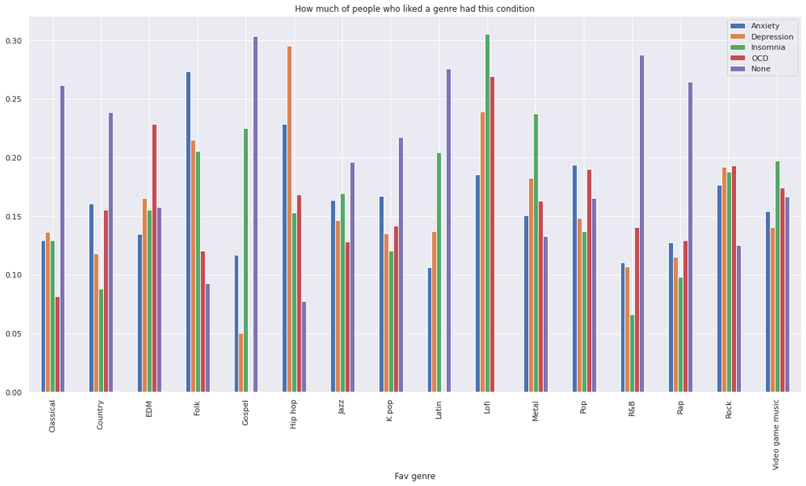

```python
genredf_copy['Total'] = genredf_copy.apply(lambda x: sum([x[i] for i in illnesses]), axis=1)
genredf_copy['Total'] = genredf_copy['None'] + genredf_copy['Total']
for i in illnesses:
  genredf_copy[i] = genredf_copy[i]/genredf_copy['Total']
fig, ax = plt.subplots(figsize=(20, 10))
genredf_copy.plot(y=illnesses, kind="bar", ax=ax)
#Percentages of all ppl that like that genre
ax.set_title("How much of people who liked a genre had this condition")
```

This is a graph for what percent of people who like each genre have any of the given mental conditions (or none.)

In order to normalize this graph we used another dataframe genredf_copy, that was a copy of genredf. Then we added another column named "Total" which had the sum of all the percentages of people that liked each genre so that we could divide everything by those numbers in order to account for the overlap of people with multiple mental illnesses.

Classical, rap, country, and R&B are all popular mainly with people with no mental illnesses.

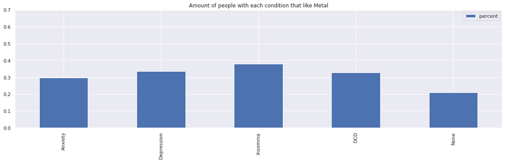

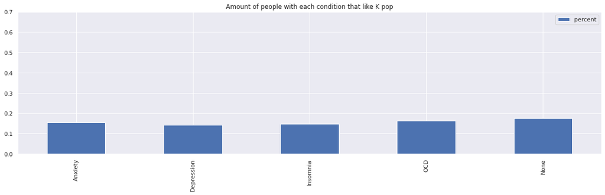

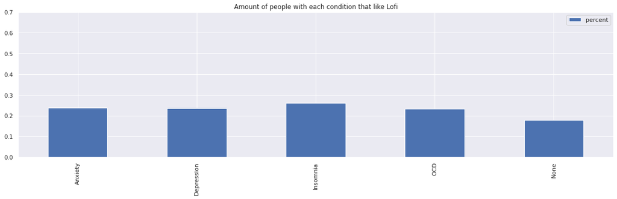

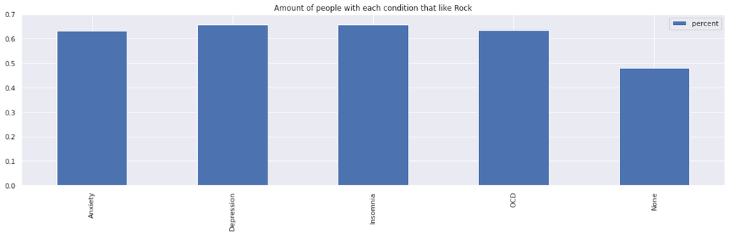

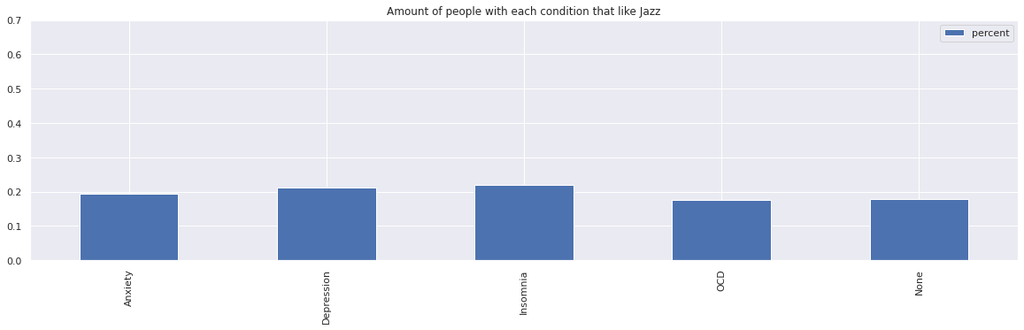

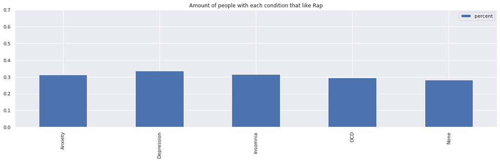

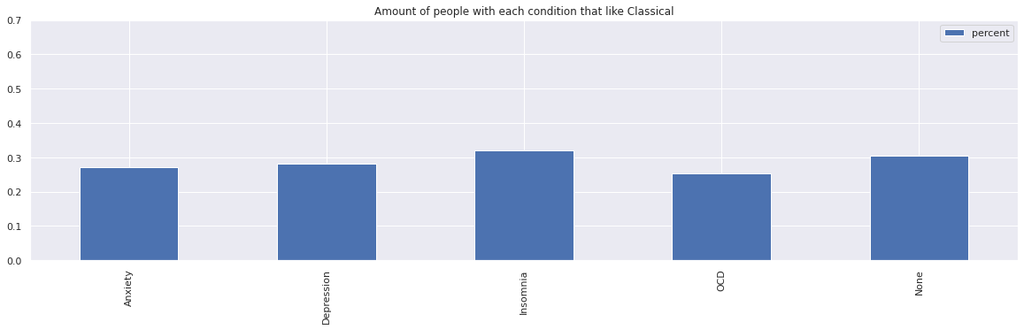

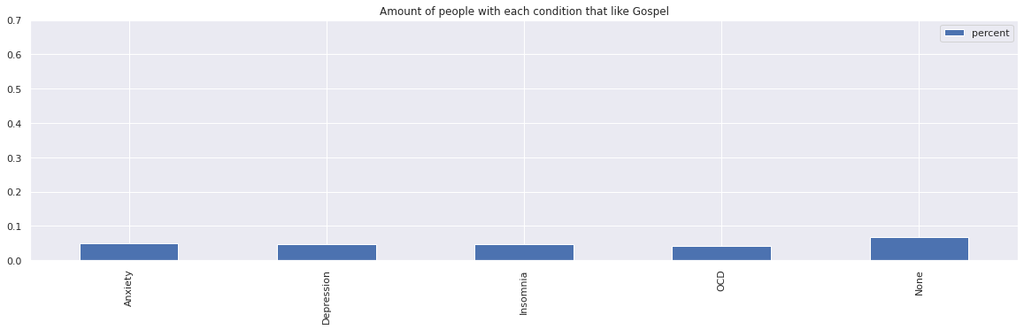

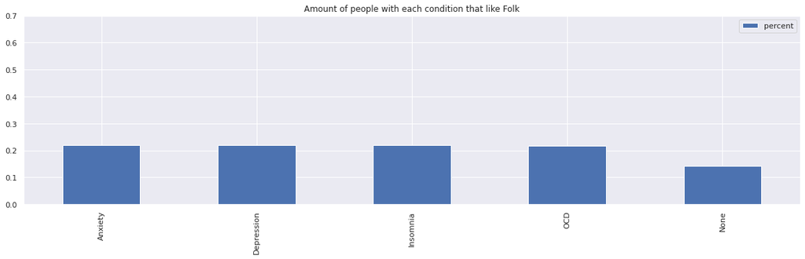

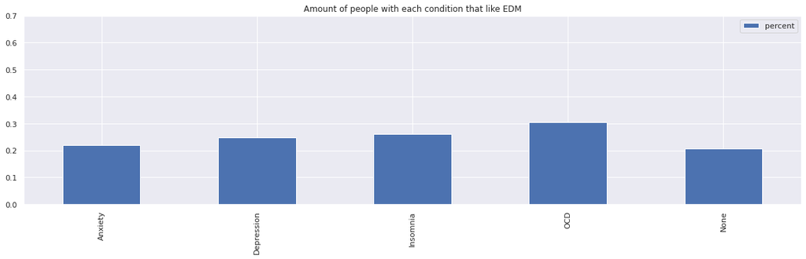

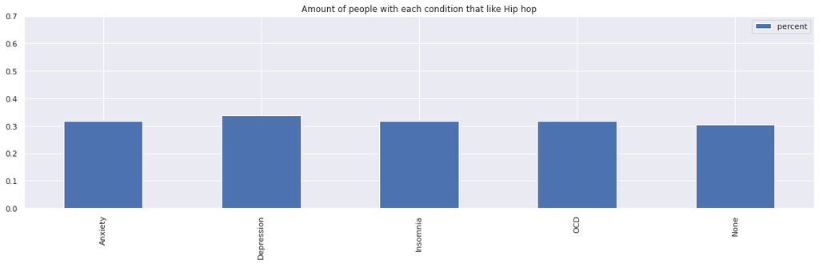

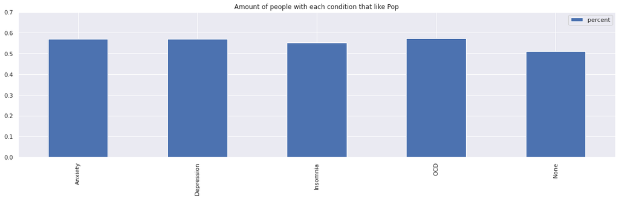

[4 more figures not shown]

```python
rankings = {"Never": 0, "Rarely": 0, "Sometimes": 1, "Very frequently": 2}

for genre in set(mxmh['Fav genre']):
  boolean_mxmh[genre + '_rank'] = boolean_mxmh.apply(lambda x: rankings[x['Frequency [%s]' % genre]], axis=1)
  values = {}
  for i in illnesses:
    values[i] = [sum(boolean_mxmh[boolean_mxmh[i] == 1][genre + '_rank']), totals[i]*2]
    table = pd.DataFrame.from_dict(values, orient='index')
  table['percent'] = table[0]/table[1]
  fig, ax = plt.subplots(figsize=(20, 5))
  ax.set_ylim(0, 0.7)
  table.plot(y='percent', kind='bar', title= "Amount of people with each condition that like " + genre, ax=ax)
```

These are graphs for how much people with each mental health condition like each genre. This is using the frequency columns instead of the usual favorite genre column.

The main graphs that stand out are rock, metal, EDM, video game music, and folk.

Rock is not only the overall, most liked genre, it is also at least about 14% more popular with people with mental health conditions than people without.

Metal is most liked by people with insomnia and least liked by people with none of the mental health conditions. There is around a 17% difference between those columns.

EDM is mainly liked by people with OCD and least liked but people with none of the the mental health conditions. There is around an 11% difference between these columns.

Folk is around 9% higher for every mental health condition than it is for no mental health conditons.

Video game music has around an 11% difference between people with insomnia and people with no mental health illnesses.

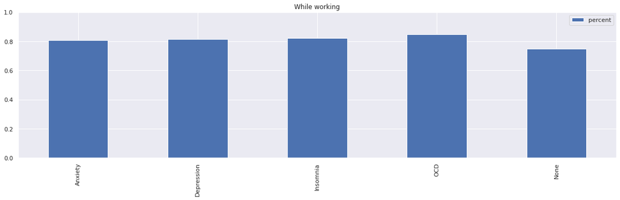

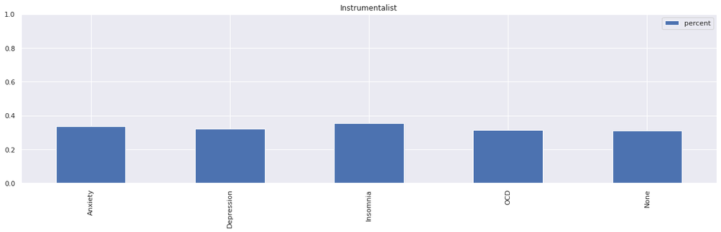

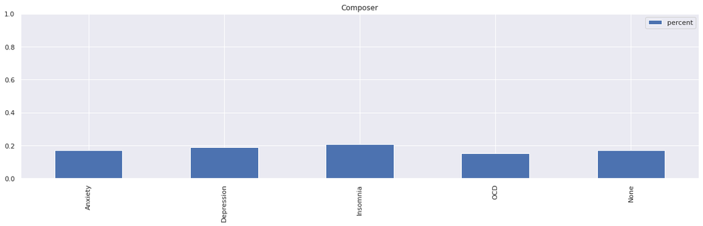

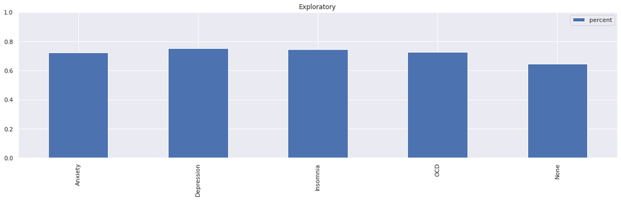

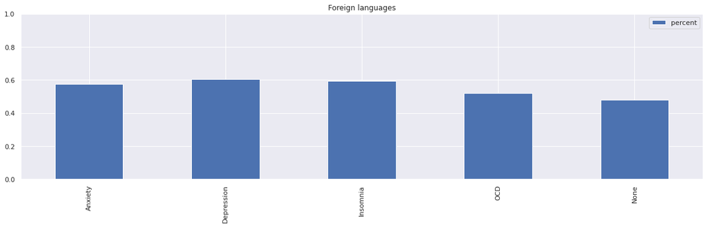

```python
for j in ['While working', 'Instrumentalist', 'Composer', 'Exploratory', 'Foreign languages']:
  boolean_mxmh[j + '_bool'] = boolean_mxmh.apply(lambda x: int(x[j] == 'Yes'), axis=1)
  values = {}
  for i in illnesses:
    values[i] = [sum(boolean_mxmh[boolean_mxmh[i] == 1][j + '_bool']), totals[i]]
    table = pd.DataFrame.from_dict(values, orient='index')
  table['percent'] = table[0]/table[1]
  fig, ax = plt.subplots(figsize=(20, 5))
  ax.set_ylim(0, 1)
  table.plot(y='percent', kind='bar', title= j, ax=ax)
```

These are graphs to explore the relationship between different mental health conditions and the binary columns that we have been given, specifically, 'While working', 'Instrumentalist', 'Composer', 'Exploratory', and 'Foreign languages'. These are all columns that have yes or no for an answer. Yes has been quantified as 1 and No has been quantified as 0.

The average has been taken for each column, for each mental illness and None.

We found no strong correlations between any of these columns and their relationship with the different mental health conditions.

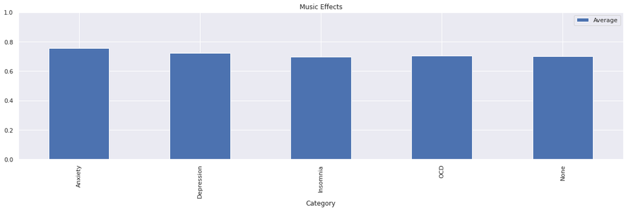

```python
values = {'Worsen': -1, 'No Effect': 0, 'Improve': 1}
values.get('Worsen')
boolean_mxmh['effect_bool'] = boolean_mxmh.apply(lambda x: values.get(x['Music effects'], 0), axis=1)
table = pd.DataFrame(columns=['Category', 'Average'])
for n, i in enumerate(illnesses):
  temp = boolean_mxmh[boolean_mxmh[i] == 1]['effect_bool']
  table.loc[n] = [i, sum(temp)/len(temp)]
fig, ax = plt.subplots(figsize=(20, 5))
ax.set_ylim(0, 1)
table.plot(y='Average', x='Category', kind='bar', title= 'Music Effects', ax=ax)
```

We quantified the mental effects column with a -1 for if they said music worsened their mental health, a 0 if they said no effect, and a 1 if they said music improved their lives.

People with anxiety reported slightly that music improved their mental health slightly more but over all there is not a huge disparity between any of these columns. Most people reported however, that music did improve their lives.

```
y = -0.011220270156887643x + 3.856364551287969
```

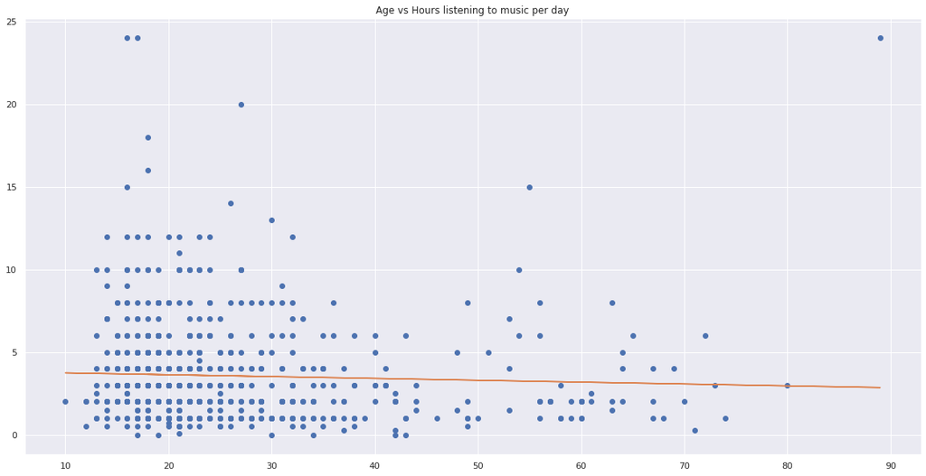

```python
from sklearn.linear_model import LinearRegression
ah = mxmh[['Age', 'Hours per day']]
ah = ah[ah['Age'].notnull()]
fig, ax = plt.subplots(figsize=(20, 10))
plt.plot(ah['Age'], ah['Hours per day'], 'o')
reg = LinearRegression().fit(ah['Age'].to_numpy().reshape(-1, 1), ah['Hours per day'])
print("y = " + str(reg.coef_[0]) + "x + " + str(reg.intercept_))
ah['expected_hpd'] = ah['Age']*reg.coef_[0] + reg.intercept_
plt.plot(ah['Age'], ah['expected_hpd'])
ax.set_title("Age vs Hours listening to music per day")
```

The average amount of hours that people spend listening to music is 4 hours. The average age for this survey is around 20. Overall people tended to be in the bottom left with a few people on the going up and some people on the bottom going to the right. There is one person who is 90 years old and listens to 24 hours of music a day. Statistically, they are an extreme outlier.

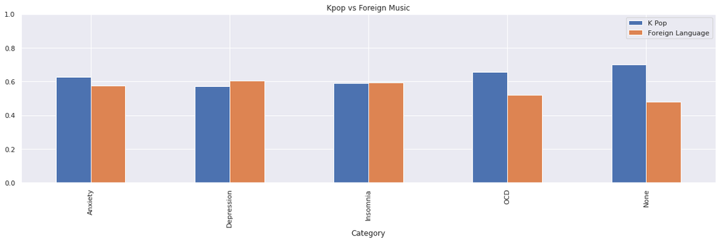

```python
rankings = {"Never": 0, "Rarely": 0, "Sometimes": 1, "Very frequently": 2}

boolean_mxmh['K Pop_rank'] = boolean_mxmh.apply(lambda x: rankings[x['Frequency [K pop]']], axis=1)
table = pd.DataFrame(columns = ['Category', 'K Pop', 'Foreign Language'])
for n, i in enumerate(illnesses):
  kpop = sum(boolean_mxmh[boolean_mxmh[i] == 1]['K Pop_rank']) / totals[i]*2
  foreign = sum(boolean_mxmh[boolean_mxmh[i] == 1]['Foreign languages_bool']) / totals[i]
  table.loc[n] = [i, kpop, foreign]
fig, ax = plt.subplots(figsize=(20, 5))
ax.set_ylim(0, 1)
table.plot(y=['K Pop', 'Foreign Language'], x='Category', kind='bar', title= "Kpop vs Foreign Music", ax=ax)
```

## 3. Modeling

```python
from sklearn.model_selection import train_test_split
from sklearn.ensemble import RandomForestClassifier
from sklearn import metrics
```

We import train_test_split from sklearn.model_selection in order to help with training the model.

We import RandomForestClassifier from sklearn.ensemble in order to help us actually build a random forest.

We import metrics from sklearn in order to help figure out how accurate the model is.

```python
accuracies_by_genre = {}
for illness in illnesses:
  model_df_X = boolean_mxmh[[i for i in boolean_mxmh.columns if '_rank' in i]]
  model_df_Y = boolean_mxmh['None']
  X_train, X_test, y_train, y_test = train_test_split(model_df_X, model_df_Y)
  clf = RandomForestClassifier(n_estimators = len(model_df_X.columns))
  clf.fit(X_train, y_train)
  y_pred = clf.predict(X_test)
  print("ACCURACY OF THE MODEL FOR %s: " % illness, metrics.accuracy_score(y_test, y_pred))
  accuracies_by_genre[illness] = metrics.accuracy_score(y_test, y_pred)
```

```
ACCURACY OF THE MODEL FOR Anxiety:  0.7554347826086957
ACCURACY OF THE MODEL FOR Depression:  0.782608695652174
ACCURACY OF THE MODEL FOR Insomnia:  0.717391304347826
ACCURACY OF THE MODEL FOR OCD:  0.7010869565217391
ACCURACY OF THE MODEL FOR None:  0.7445652173913043
```

We created a model that takes in the input of a person's music preferences, if the model returned a 1 they had no mental illnesses and if it returned a 0 that meant they were likely to have some kind of mental illness.

## 4. Hypothesis Testing

Here we are testing various linear regressions in order to see if there are any correlations that we were not able to see in the graphs. As well as see if there is a real correlation between what we observed in the graphs.

```python
import statsmodels.api as sm
temp = [i for i in illnesses if i != 'None']
for i in temp:
  X = mxmh['Hours per day']
  y = mxmh[i]
  X = sm.add_constant(X)
  mod = sm.OLS(y, X).fit()
  print(i)
  print(mod.summary())
```

```
Anxiety
                            OLS Regression Results
==============================================================================
Dep. Variable:                Anxiety   R-squared:                       0.002
Model:                            OLS   Adj. R-squared:                  0.001
Method:                 Least Squares   F-statistic:                     1.790
Date:                Sat, 17 Dec 2022   Prob (F-statistic):              0.181
Time:                        04:45:35   Log-Likelihood:                -1798.9
No. Observations:                 736   AIC:                             3602.
Df Residuals:                     734   BIC:                             3611.
Df Model:                           1
Covariance Type:            nonrobust
=================================================================================
                    coef    std err          t      P>|t|      [0.025      0.975]
---------------------------------------------------------------------------------
const             5.6751      0.159     35.646      0.000       5.363       5.988
Hours per day     0.0455      0.034      1.338      0.181      -0.021       0.112
==============================================================================
Omnibus:                       67.766   Durbin-Watson:                   1.949
Prob(Omnibus):                  0.000   Jarque-Bera (JB):               39.638
Skew:                          -0.427   Prob(JB):                     2.47e-09
Kurtosis:                       2.249   Cond. No.                         7.44
==============================================================================

Notes:
[1] Standard Errors assume that the covariance matrix of the errors is correctly specified.
Depression
                            OLS Regression Results
==============================================================================
Dep. Variable:             Depression   R-squared:                       0.012
Model:                            OLS   Adj. R-squared:                  0.011
Method:                 Least Squares   F-statistic:                     9.078
Date:                Sat, 17 Dec 2022   Prob (F-statistic):            0.00268
Time:                        04:45:35   Log-Likelihood:                -1854.9
No. Observations:                 736   AIC:                             3714.
Df Residuals:                     734   BIC:                             3723.
Df Model:                           1
Covariance Type:            nonrobust
=================================================================================
                    coef    std err          t      P>|t|      [0.025      0.975]
```

[output cut: 49 more lines]

```
Covariance Type:            nonrobust
=================================================================================
                    coef    std err          t      P>|t|      [0.025      0.975]
---------------------------------------------------------------------------------
const             2.2391      0.161     13.904      0.000       1.923       2.555
Hours per day     0.1114      0.034      3.240      0.001       0.044       0.179
==============================================================================
Omnibus:                       80.453   Durbin-Watson:                   1.882
Prob(Omnibus):                  0.000   Jarque-Bera (JB):              106.699
Skew:                           0.931   Prob(JB):                     6.77e-24
Kurtosis:                       2.897   Cond. No.                         7.44
==============================================================================

Notes:
[1] Standard Errors assume that the covariance matrix of the errors is correctly specified.
```

```python
from scipy.stats import f_oneway
from scipy.stats import ttest_ind_from_stats
import statistics
```

We imported f_oneway from scipy.stats to help us conduct ANOVA tests.

We imported ttest_ind_from_stats from scipy.stats to help us conduct t-tests.

We imported statistics in order to help us analyze the results we get from the tests.

```python
df = pd.DataFrame()
for genre in ['Rock', 'Gospel', 'Classical', 'EDM']:
  values = {}
  for i in illnesses:
    values[i] = list(boolean_mxmh[boolean_mxmh[i] == 1][genre + '_rank'])
  print(genre, " = ", f_oneway(values['Anxiety'], values['Depression'], values['OCD'], values['Insomnia'], values['None']))
```

```
Rock  =  F_onewayResult(statistic=6.623246039756143, pvalue=2.817915176968885e-05)
Gospel  =  F_onewayResult(statistic=0.5278424110776132, pvalue=0.7153003415236621)
Classical  =  F_onewayResult(statistic=1.1168825267140747, pvalue=0.34691526486779656)
EDM  =  F_onewayResult(statistic=2.0276364650774674, pvalue=0.08827295166802818)
```

We ran a one way ANOVA for rock, gospel, classical, and EDM as they stood out the most to us throughout our graphs.

Gospel and Classical have relatively high p-values in comparison.

```python
#Rock t-test mentally ill in general vs not mentally ill (since all of the mentally ill ones had similar heights, and only none looked distinctively different)
a = list(boolean_mxmh[boolean_mxmh['None'] == 1]['Rock_rank'])
b = list(boolean_mxmh[boolean_mxmh['None'] == 0]['Rock_rank'])
ttest_ind_from_stats(statistics.mean(a), statistics.stdev(a), len(a), statistics.mean(b), statistics.mean(b), len(b))
```

```
Ttest_indResult(statistic=-2.972457914973402, pvalue=0.0030509002354740062)
```

This is a t-test of people who are mentally ill vs people who aren't and how much they like rock. This has a p-value of 0.003 so there is a statistically significant difference between these groups of people.

```python
#EDM t-test OCD vs not mentally ill
a = list(boolean_mxmh[boolean_mxmh['None'] == 1]['EDM_rank'])
b = list(boolean_mxmh[boolean_mxmh['OCD'] == 1]['EDM_rank'])
ttest_ind_from_stats(statistics.mean(a), statistics.stdev(a), len(a), statistics.mean(b), statistics.mean(b), len(b))
```

```
Ttest_indResult(statistic=-2.557540743171967, pvalue=0.011033149379147653)
```

This is a t-test of people who have OCD vs people who don't have any mental health conditions and how much they like EDM. This has a p-value of 0.011 so there is a statistically significant difference between these groups of people.

```python
#Metal t-test Insomnia vs not mentally ill
a = list(boolean_mxmh[boolean_mxmh['None'] == 1]['Metal_rank'])
b = list(boolean_mxmh[boolean_mxmh['Insomnia'] == 1]['Metal_rank'])
ttest_ind_from_stats(statistics.mean(a), statistics.stdev(a), len(a), statistics.mean(b), statistics.mean(b), len(b))
```

```
Ttest_indResult(statistic=-4.441028638641283, pvalue=1.1600166123990394e-05)
```

This is a t-test of people who have Insomnia vs people who don't have any mental health conditions and how much they like metal. This has a p-value of 1.16 * 10^-5 so there is a statistically significant difference between these groups of people.

```python
#Folk t-test Anxiety vs not mentally ill
a = list(boolean_mxmh[boolean_mxmh['None'] == 1]['Folk_rank'])
b = list(boolean_mxmh[boolean_mxmh['Anxiety'] == 1]['Folk_rank'])
ttest_ind_from_stats(statistics.mean(a), statistics.stdev(a), len(a), statistics.mean(b), statistics.mean(b), len(b))
```

```
Ttest_indResult(statistic=-3.4774661879896303, pvalue=0.0005420074336636641)
```

This is a t-test of people who have anxiety vs people who don't have any mental health conditions and how much they like folk. This has a p-value of 0.0005 so there is a statistically significant difference between these groups of people.

```python
#Video Game Music t-test Insomnia vs not mentally ill
a = list(boolean_mxmh[boolean_mxmh['None'] == 1]['Video game music_rank'])
b = list(boolean_mxmh[boolean_mxmh['Insomnia'] == 1]['Video game music_rank'])
ttest_ind_from_stats(statistics.mean(a), statistics.stdev(a), len(a), statistics.mean(b), statistics.mean(b), len(b))
```

```
Ttest_indResult(statistic=-3.1253381355909107, pvalue=0.001905560239040283)
```

This is a t-test of people who have Insomnia vs people who don't have any mental health conditions and how much they like video game music. This has a p-value of 0.0019 so there is a statistically significant difference between these groups of people.

```python
#BPM t-test mentally ill vs not mentally ill
a = list(boolean_mxmh[boolean_mxmh['None'] == 1]['BPM'].notnull())
b = list(boolean_mxmh[boolean_mxmh['None'] == 0]['BPM'].notnull())
ttest_ind_from_stats(statistics.mean(a), statistics.stdev(a), len(a), statistics.mean(b), statistics.mean(b), len(b))
```

```
Ttest_indResult(statistic=-0.6860581500280111, pvalue=0.4928930832826217)
```

```python
#Classical t-test mentally ill vs not mentally ill
a = list(boolean_mxmh[boolean_mxmh['None'] == 1]['Classical_rank'])
b = list(boolean_mxmh[boolean_mxmh['None'] == 0]['Classical_rank'])
ttest_ind_from_stats(statistics.mean(a), statistics.stdev(a), len(a), statistics.mean(b), statistics.mean(b), len(b))
```

```
Ttest_indResult(statistic=1.0482561732617188, pvalue=0.2948656351641847)
```

This is a test of people who have any of the mental health conditions vs people who don't have any mental health conditions and how much they liked classical music. This has a p-value of 0.29 so there is not a statistically significant difference between these groups of people for this.

```python
#Country t-test mentally ill vs not mentally ill
a = list(boolean_mxmh[boolean_mxmh['None'] == 1]['Country_rank'])
b = list(boolean_mxmh[boolean_mxmh['None'] == 0]['Country_rank'])
ttest_ind_from_stats(statistics.mean(a), statistics.stdev(a), len(a), statistics.mean(b), statistics.mean(b), len(b))
```

```
Ttest_indResult(statistic=1.4850001324692907, pvalue=0.13797311587511268)
```

```python
#R&B t-test mentally ill vs not mentally ill
a = list(boolean_mxmh[boolean_mxmh['None'] == 1]['R&B_rank'])
b = list(boolean_mxmh[boolean_mxmh['None'] == 0]['R&B_rank'])
ttest_ind_from_stats(statistics.mean(a), statistics.stdev(a), len(a), statistics.mean(b), statistics.mean(b), len(b))
```

```
Ttest_indResult(statistic=-0.3792073314056042, pvalue=0.7046435812270304)
```

This is a test of people who have any of the mental health conditions vs people who don't have any mental health conditions and how much they liked R&B music. This has a p-value of 0.7 so there is not a statistically significant difference between these groups of people for this.

# Conclusions

Overall we explored a lot of relationships between music and mental health.

Despite these differences though, most people claimed that music did positively impact their lives. It's interesting to consider this when you know that people have such varied taste and approaches to what impact music has in their lives. It could speak to the variability in music therapy and how a slightly different approach is needed for each person.

However, while we can find significant correlations, it's important to remember that these are just correlations, one's mental state cannot be determined by their music tastes and vice versa.

Citations: \

Baker F, Bor W. Can Music Preference Indicate Mental Health Status in Young People? Australasian Psychiatry. 2008;16(4):284-288. doi:10.1080/10398560701879589

Lin, S. T., Yang, P., Lai, C. Y., Su, Y. Y., Yeh, Y. C., Huang, M. F., & Chen, C. C. (2011). Mental health implications of music: Insight from neuroscientific and clinical studies. Harvard review of psychiatry, 19(1), 34-46.